# Project_2

Ignat Sonets

11/27/2020

Приветствую! Нам было бы очень интересно посмотреть на то, как средняя стоимость домов (переменная medv, измерена в 1000 долларов), занимаемых владельцами, зависит от различных факторов. Это и будет нашей целью.нам нужно это для того, что заказчик исследования спрашивает, как же должен выглядеть идеальный район для постройки дома. Решением для этой задачи выступит использование линейных моделей.

# 0. Установка и загрузка библиотек

```r
pckgs <- c('dplyr', 'ggplot2', 'car', 'psych', 'corrplot', 'MASS', 'gridExtra')
for(i in pckgs){
  if(!require(i, character.only = T)){
    install.packages(i, dependencies = T)
    library(i)
  }
}
```

```r
library(dplyr)
library(ggplot2)
library(car)
library(psych)
library(corrplot)
library(MASS)
library(gridExtra)
```

# 1. Строим линейную модель

Загружаем данные:

```r
data <- Boston
str(data)
```

```
## 'data.frame':    506 obs. of  14 variables:
##  $ crim   : num  0.00632 0.02731 0.02729 0.03237 0.06905 ...
##  $ zn     : num  18 0 0 0 0 0 12.5 12.5 12.5 12.5 ...
##  $ indus  : num  2.31 7.07 7.07 2.18 2.18 2.18 7.87 7.87 7.87 7.87 ...
##  $ chas   : int  0 0 0 0 0 0 0 0 0 0 ...
##  $ nox    : num  0.538 0.469 0.469 0.458 0.458 0.458 0.524 0.524 0.524 0.524 ...
##  $ rm     : num  6.58 6.42 7.18 7 7.15 ...
##  $ age    : num  65.2 78.9 61.1 45.8 54.2 58.7 66.6 96.1 100 85.9 ...
##  $ dis    : num  4.09 4.97 4.97 6.06 6.06 ...
##  $ rad    : int  1 2 2 3 3 3 5 5 5 5 ...
##  $ tax    : num  296 242 242 222 222 222 311 311 311 311 ...
##  $ ptratio: num  15.3 17.8 17.8 18.7 18.7 18.7 15.2 15.2 15.2 15.2 ...
##  $ black  : num  397 397 393 395 397 ...
##  $ lstat  : num  4.98 9.14 4.03 2.94 5.33 ...
##  $ medv   : num  24 21.6 34.7 33.4 36.2 28.7 22.9 27.1 16.5 18.9 ...
```

```r
summary(data)
```

```
##       crim                zn             indus            chas
##  Min.   : 0.00632   Min.   :  0.00   Min.   : 0.46   Min.   :0.00000
##  1st Qu.: 0.08204   1st Qu.:  0.00   1st Qu.: 5.19   1st Qu.:0.00000
##  Median : 0.25651   Median :  0.00   Median : 9.69   Median :0.00000
##  Mean   : 3.61352   Mean   : 11.36   Mean   :11.14   Mean   :0.06917
##  3rd Qu.: 3.67708   3rd Qu.: 12.50   3rd Qu.:18.10   3rd Qu.:0.00000
##  Max.   :88.97620   Max.   :100.00   Max.   :27.74   Max.   :1.00000
##       nox               rm             age              dis
##  Min.   :0.3850   Min.   :3.561   Min.   :  2.90   Min.   : 1.130
##  1st Qu.:0.4490   1st Qu.:5.886   1st Qu.: 45.02   1st Qu.: 2.100
##  Median :0.5380   Median :6.208   Median : 77.50   Median : 3.207
##  Mean   :0.5547   Mean   :6.285   Mean   : 68.57   Mean   : 3.795
##  3rd Qu.:0.6240   3rd Qu.:6.623   3rd Qu.: 94.08   3rd Qu.: 5.188
##  Max.   :0.8710   Max.   :8.780   Max.   :100.00   Max.   :12.127
##       rad              tax           ptratio          black
##  Min.   : 1.000   Min.   :187.0   Min.   :12.60   Min.   :  0.32
##  1st Qu.: 4.000   1st Qu.:279.0   1st Qu.:17.40   1st Qu.:375.38
##  Median : 5.000   Median :330.0   Median :19.05   Median :391.44
##  Mean   : 9.549   Mean   :408.2   Mean   :18.46   Mean   :356.67
##  3rd Qu.:24.000   3rd Qu.:666.0   3rd Qu.:20.20   3rd Qu.:396.23
##  Max.   :24.000   Max.   :711.0   Max.   :22.00   Max.   :396.90
##      lstat            medv
##  Min.   : 1.73   Min.   : 5.00
##  1st Qu.: 6.95   1st Qu.:17.02
##  Median :11.36   Median :21.20
##  Mean   :12.65   Mean   :22.53
##  3rd Qu.:16.95   3rd Qu.:25.00
##  Max.   :37.97   Max.   :50.00
```

Итого имеем 506 наблюдений и 14 переменных: **Переменные:** *crim* -число преступлений на душу населения *zn* -доля земли под жилую застройку, зонированная под участки площадью более 25 000 кв. футов. *indus* -доля акров, не относящихся к розничной торговле, на город. *chas* -Переменная-индикатор(1, если дорога пересекает реку Чарльз, 0, если не пересекает) *nox* -концентрация оксидов азота(частицы/10 млн) *rm* -среднее количество комнат в доме *age* -доля жилых населяемых домов, построенных до 1940 г. *dis* -средневзвешенное расстояние до пяти бостонских центров занятости. *rad* -индекс доступности радиальных магистралей *tax* -полная ставка налога на имущество за каждые 10 000 долларов. *ptratio* -отношение “ученик/учитель” в городе *black* -1000(Bk - 0.63)^2, где Bk – доля чернокожих в городе *lstat* -% населения никзого статуса *medv* -медианная стоимость домов(*1000$)

Проверим на NA:

```r
NAs <- length(which(is.na(data)==T))
if (NAs>0) {data <- data[complete.cases(data),]
}
```

NA отсутствуют, но подстраховаться от ошибок – хорошая практика. Сделаем *chas* факторной переменной:

```r
data$chas <- factor(data$chas)
```

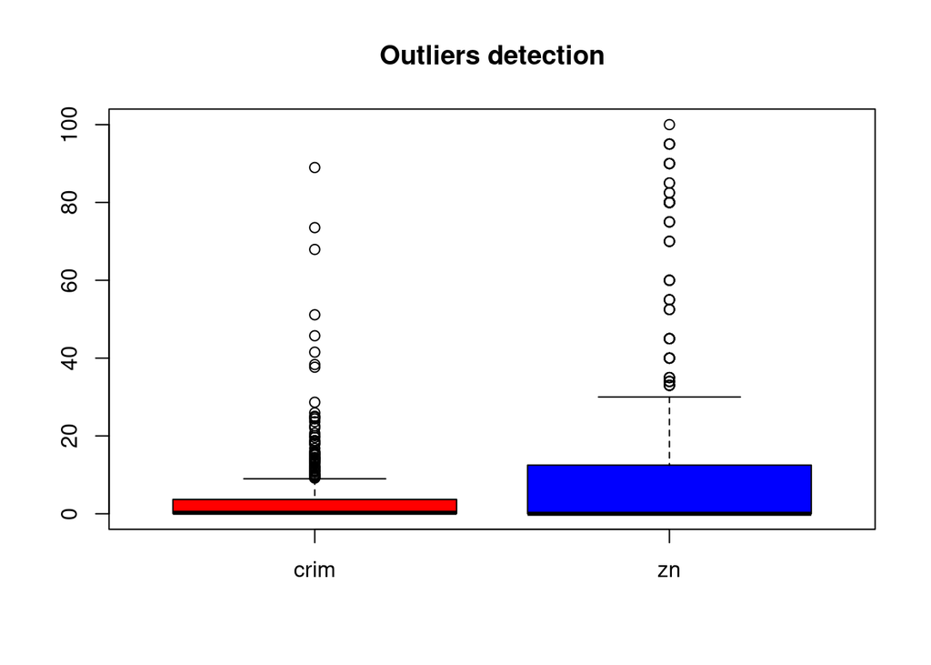

```r
boxplot(data$crim, data$zn, main = 'Outliers detection', col=c('red','blue'),names = c('crim', 'zn'))
```

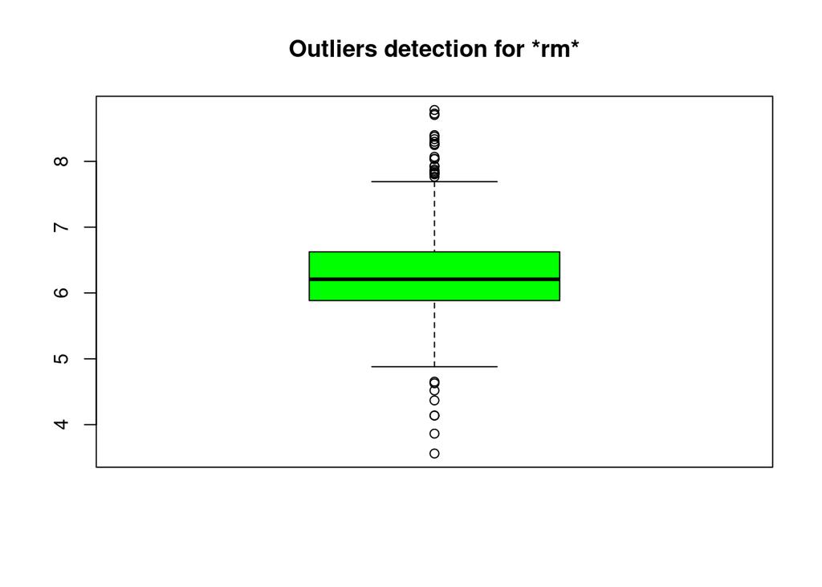

```r
boxplot(data$rm, main='Outliers detection for *rm*', col = 'green', names = c('rm'))
```

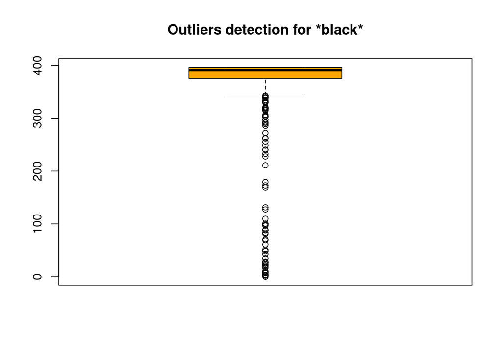

```r
boxplot(data$black, main='Outliers detection for *black*', col = 'orange')
```

Да, выбросов действительно хватает. Что с ним можно сделать? На данный момент я бы предпочел не трогать имеющиеся данные. Иначе лин.модель будет предсказывать для *новых* значений, а не для наших данных. И выводы могут получиться соврешенно другими. В принципе, можно будет выкинуть выбросы целиком, но пока что не будем этого делать.

Для применения линейной модели нам также важно знать об отсутствии корреляции между переменными. это важно для дальнейшей проверки модели на мультиколлинеарность модели.

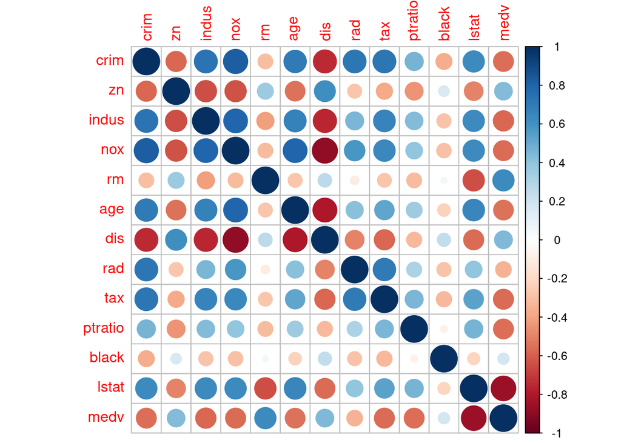

```r
drops <- c('chas')
corr_matrix <- cor(x = data[, !names(data) %in% drops], y = NULL, method = c("spearman"))
corrplot(corr_matrix)
```

Какие выводы можно сделать? 1. Крайне сильная корреляция (0,9)- между *rad* и *tax*: чем больше доступно магистралей, тем выше ставка. 2. Сильная отрицательная корреляция между *dis* и *indus*, *nox*, *age*.Т.е. эти районы старые, там мало жилья и плохой воздух, и до центров занятости оттуда далеко.Не лучшее место. 3. Сильная отр. корреляция между *lstat* и *medv*, что логично – небогатое население живет в дешевом жилье. 4. Сильная положительная корреляция между *indus* и *nox*( индустриальные кварталы сильнее загрязняют воздух) 5. Сильная положительная корреляция между *indus* и *tax*(промышленность платит более высокие налоги) 6. Сильная положительная корреляция между *nox* и *age*(в старых районах воздух загрязнен сильнее) 7. Сильная положительная корреляция между *rm* и *medv*(больше комнат – дороже жилье) Уже сейчас можно делать некоторые выводы о выборе идеального дома, но лучше подкрепить это расчетами. Однако стоит учесть то, что предикторы мультиколлинеарны, что может осложнить нам задачу в будущем.

Вас(заказчика) особенно интересует стоимость домов. Тогда построим линейную модель для предсказания стоимости домов в зависимости от различных факторов района вокруг дома.

```r
mod_1 <- lm(medv ~ ., data = data)
summary(mod_1)
```

```
##
## Call:
## lm(formula = medv ~ ., data = data)
##
## Residuals:
##     Min      1Q  Median      3Q     Max
## -15.595  -2.730  -0.518   1.777  26.199
##
## Coefficients:
##               Estimate Std. Error t value Pr(>|t|)
## (Intercept)  3.646e+01  5.103e+00   7.144 3.28e-12 ***
## crim        -1.080e-01  3.286e-02  -3.287 0.001087 **
## zn           4.642e-02  1.373e-02   3.382 0.000778 ***
## indus        2.056e-02  6.150e-02   0.334 0.738288
## chas1        2.687e+00  8.616e-01   3.118 0.001925 **
## nox         -1.777e+01  3.820e+00  -4.651 4.25e-06 ***
## rm           3.810e+00  4.179e-01   9.116  < 2e-16 ***
## age          6.922e-04  1.321e-02   0.052 0.958229
## dis         -1.476e+00  1.995e-01  -7.398 6.01e-13 ***
## rad          3.060e-01  6.635e-02   4.613 5.07e-06 ***
## tax         -1.233e-02  3.760e-03  -3.280 0.001112 **
## ptratio     -9.527e-01  1.308e-01  -7.283 1.31e-12 ***
## black        9.312e-03  2.686e-03   3.467 0.000573 ***
## lstat       -5.248e-01  5.072e-02 -10.347  < 2e-16 ***
## ---
## Signif. codes:  0 '***' 0.001 '**' 0.01 '*' 0.05 '.' 0.1 ' ' 1
##
## Residual standard error: 4.745 on 492 degrees of freedom
## Multiple R-squared:  0.7406, Adjusted R-squared:  0.7338
## F-statistic: 108.1 on 13 and 492 DF,  p-value: < 2.2e-16
```

Стандартизуем предикторы, чтобы найти самый влиятельный предиктор(также это необходимо потому, что разные переменнные имеют разные единицы измерений, и сравнивать напрямую некорреткно):

```r
mod_1_scaled <- lm(medv ~ ., data = as.data.frame(sapply(data[,-4], scale)))
summary(mod_1_scaled)
```

```
##
## Call:
## lm(formula = medv ~ ., data = as.data.frame(sapply(data[, -4],
##     scale)))
##
## Residuals:
##      Min       1Q   Median       3Q      Max
## -1.45663 -0.30556 -0.07019  0.20812  2.86780
##
## Coefficients:
##               Estimate Std. Error t value Pr(>|t|)
## (Intercept) -1.343e-16  2.314e-02   0.000 1.000000
## crim        -1.058e-01  3.097e-02  -3.417 0.000686 ***
## zn           1.193e-01  3.511e-02   3.398 0.000734 ***
## indus        3.007e-02  4.603e-02   0.653 0.513889
## nox         -2.188e-01  4.852e-02  -4.509 8.13e-06 ***
## rm           2.942e-01  3.219e-02   9.137  < 2e-16 ***
## age          8.520e-03  4.073e-02   0.209 0.834407
## dis         -3.401e-01  4.606e-02  -7.383 6.64e-13 ***
## rad          3.108e-01  6.300e-02   4.934 1.10e-06 ***
## tax         -2.521e-01  6.901e-02  -3.653 0.000287 ***
## ptratio     -2.333e-01  3.093e-02  -7.542 2.25e-13 ***
## black        9.670e-02  2.686e-02   3.600 0.000351 ***
## lstat       -4.147e-01  3.965e-02 -10.459  < 2e-16 ***
## ---
## Signif. codes:  0 '***' 0.001 '**' 0.01 '*' 0.05 '.' 0.1 ' ' 1
##
## Residual standard error: 0.5205 on 493 degrees of freedom
## Multiple R-squared:  0.7355, Adjusted R-squared:  0.7291
## F-statistic: 114.3 on 12 and 493 DF,  p-value: < 2.2e-16
```

После стандартизации коэффициенты измерены в стандартных отклонениях и их можно корректно сравнивать и обрабатывать.

Модель объясняет примерно 74% изменчивости (adj. R-squared = 0.7338). F-статистика = 108.1

Модель не идеальна, но ее оптимизацию мы проведем позже.

# 2. Диагностика модели

Условия применимости линейных моделей: * линейность связи (=отсутствие паттерна в остатках)  
* отсутствие влиятельных наблюдений * независимость наблюдений * нормальное распределение * постоянство дисперсии (=отсутствие гетероскедастичности) * отсутствие коллинеарности предикторов

Воспользуемся *ggplot2* и функцией *fortify()*

```r
mod_diag <- fortify(mod_1)
head(mod_diag)
```

```
##   medv    crim zn indus chas   nox    rm  age    dis rad tax ptratio
## 1 24.0 0.00632 18  2.31    0 0.538 6.575 65.2 4.0900   1 296    15.3
## 2 21.6 0.02731  0  7.07    0 0.469 6.421 78.9 4.9671   2 242    17.8
## 3 34.7 0.02729  0  7.07    0 0.469 7.185 61.1 4.9671   2 242    17.8
## 4 33.4 0.03237  0  2.18    0 0.458 6.998 45.8 6.0622   3 222    18.7
## 5 36.2 0.06905  0  2.18    0 0.458 7.147 54.2 6.0622   3 222    18.7
## 6 28.7 0.02985  0  2.18    0 0.458 6.430 58.7 6.0622   3 222    18.7
##    black lstat       .hat   .sigma      .cooksd  .fitted    .resid
## 1 396.90  4.98 0.01692479 4.742261 0.0020024118 30.00384 -6.003843
## 2 396.90  9.14 0.01110918 4.747583 0.0004228574 25.02556 -3.425562
## 3 392.83  4.03 0.01182295 4.746422 0.0006558535 30.56760  4.132403
## 4 394.63  2.94 0.01569642 4.745122 0.0011805806 28.60704  4.792964
## 5 396.90  5.33 0.01610951 4.735251 0.0035985143 27.94352  8.256476
## 6 394.12  5.21 0.01481479 4.747547 0.0005741947 25.25628  3.443716
##    .stdresid
## 1 -1.2760641
## 2 -0.7259291
## 3  0.8760357
## 4  1.0180663
## 5  1.7541140
## 6  0.7311472
```

## 2.1. График расстояний Кука

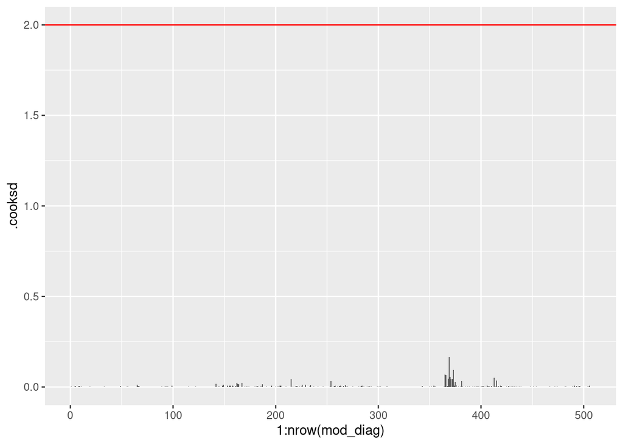

```r
ggplot(mod_diag, aes(x = 1:nrow(mod_diag), y = .cooksd)) +
  geom_bar(stat = "identity") +
  geom_hline(yintercept = 2, color = "red")
```

Ни одно значение не превышает условного порога в 2 единицы. Влиятельных наблюдений нет.

## 2.2. График остатков модели от предсказанных значений

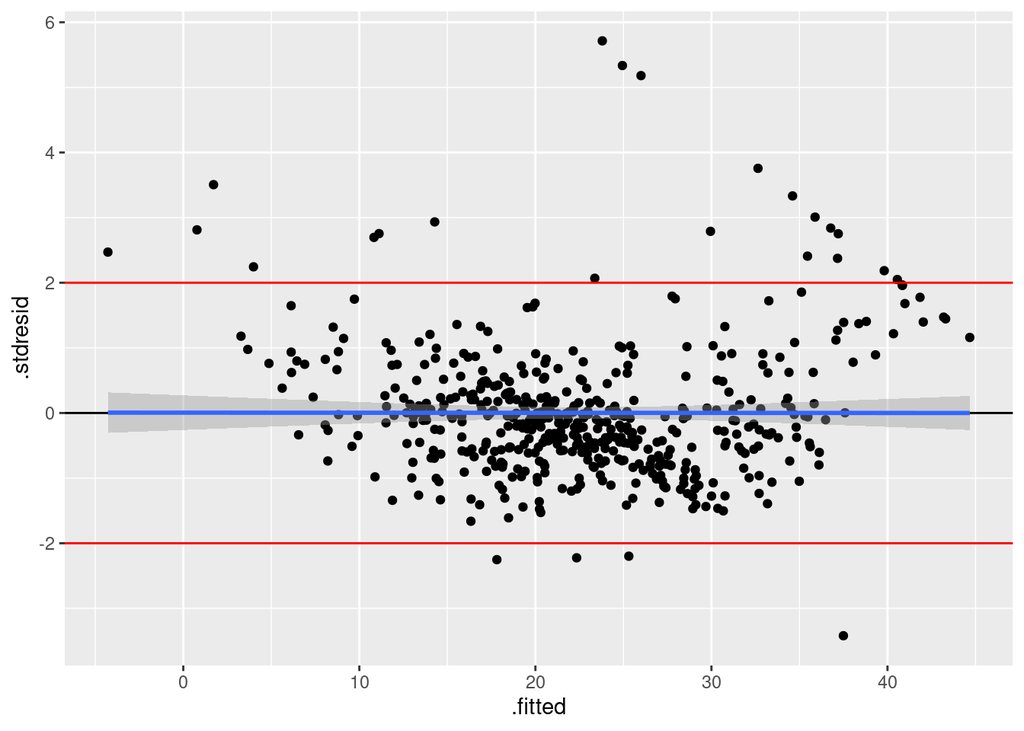

```r
gg_resid <- ggplot(data = mod_diag, aes(x = .fitted, y = .stdresid)) +
  geom_point() +
  geom_hline(yintercept = 0)+
  geom_hline(yintercept = 2, color = "red") +
  geom_hline(yintercept = -2, color = "red") +
  geom_smooth(method = 'lm')
gg_resid
```

Нелинейности не обнаружено. Но не все наблюдения находятся в зоне +/- 2 стандартных отклонения. Вероятно, что это происходит из-за наличия выбросов в изначальных данных. Не обнаружено гетероскедастичности (паттерн в форме воронки).

## 2.3. Проверка на нормальность распеределения

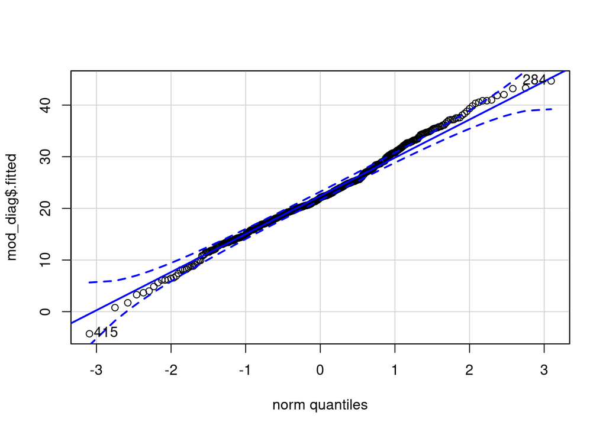

```
## [1] 415 284
```

```r
qqPlot(mod_diag$.fitted)
```

Распределение более или менее соответствует нормальному. Думаю, в нашем случае некоторое отличие от идеала не критично.

## 2.4. Проверка модели на коллинеарность предикторов

Используем метод VIF. Если предиктор имеет значение VIF выше 2, то его следует исключать из модели.

```r
vif(mod_1)
```

```
##     crim       zn    indus     chas      nox       rm      age      dis
## 1.792192 2.298758 3.991596 1.073995 4.393720 1.933744 3.100826 3.955945
##      rad      tax  ptratio    black    lstat
## 7.484496 9.008554 1.799084 1.348521 2.941491
```

```r
mod_2 <- update(mod_1, .~. - tax)
vif(mod_2)
```

```
##     crim       zn    indus     chas      nox       rm      age      dis
## 1.791940 2.184240 3.226015 1.058220 4.369271 1.923075 3.098044 3.954446
##      rad  ptratio    black    lstat
## 2.837494 1.788839 1.347564 2.940800
```

```r
mod_3 <- update(mod_2, .~. - dis)
vif(mod_3)
```

```
##     crim       zn    indus     chas      nox       rm      age      rad
## 1.767378 1.803270 3.062153 1.057867 4.023487 1.887815 2.835863 2.837492
##  ptratio    black    lstat
## 1.772568 1.346882 2.936518
```

```r
mod_4 <- update(mod_3, .~. - nox)
vif(mod_4)
```

```
##     crim       zn    indus     chas       rm      age      rad  ptratio
## 1.765881 1.758636 2.517520 1.056840 1.879925 2.423551 2.507024 1.530992
##    black    lstat
## 1.339553 2.926111
```

```r
mod_5 <- update(mod_4, .~. - lstat)
vif(mod_5)
```

```
##     crim       zn    indus     chas       rm      age      rad  ptratio
## 1.727110 1.751140 2.489395 1.053402 1.307312 2.038976 2.497242 1.529761
##    black
## 1.304899
```

```r
mod_6 <- update(mod_5, .~. - rad)
vif(mod_6)
```

```
##     crim       zn    indus     chas       rm      age  ptratio    black
## 1.372553 1.738620 2.229252 1.052519 1.281667 2.026045 1.369726 1.251785
```

```r
mod_7 <- update(mod_6, .~. - indus)
vif(mod_7)
```

```
##     crim       zn     chas       rm      age  ptratio    black
## 1.342583 1.680416 1.043732 1.216701 1.668190 1.345528 1.209887
```

```r
summary(mod_7)
```

```
##
## Call:
## lm(formula = medv ~ crim + zn + chas + rm + age + ptratio + black,
##     data = data)
##
## Residuals:
##     Min      1Q  Median      3Q     Max
## -19.344  -2.952  -0.752   1.686  39.739
##
## Coefficients:
##              Estimate Std. Error t value Pr(>|t|)
## (Intercept) -7.059509   4.174778  -1.691 0.091464 .
## crim        -0.107763   0.033452  -3.221 0.001359 **
## zn          -0.003106   0.013803  -0.225 0.822060
## chas1        3.520275   0.998861   3.524 0.000464 ***
## rm           7.064243   0.389859  18.120  < 2e-16 ***
## age         -0.041439   0.011395  -3.637 0.000305 ***
## ptratio     -0.927928   0.133056  -6.974 9.84e-12 ***
## black        0.014984   0.002992   5.008 7.65e-07 ***
## ---
## Signif. codes:  0 '***' 0.001 '**' 0.01 '*' 0.05 '.' 0.1 ' ' 1
##
## Residual standard error: 5.581 on 498 degrees of freedom
## Multiple R-squared:  0.6369, Adjusted R-squared:  0.6318
## F-statistic: 124.8 on 7 and 498 DF,  p-value: < 2.2e-16
```

Итого мы имеем модель **medv = -7.06 - 0.1 * crim - 0.003 * zn + 3.5 * chas + 7.06 * rm - 0.04 * age - 0.93 * ptratio + 0.015 * black** .

В модели не осталось мультиколлинеарности. Но после фильтрации модель потеряла примерно 10% точности(adj. R-squared = 0.6318). Не идеально, но лучше, чем ничего.

Помимо стандартных графиков для множественных моделей необходимо строить графики от предикторов, не вошедших в модель.

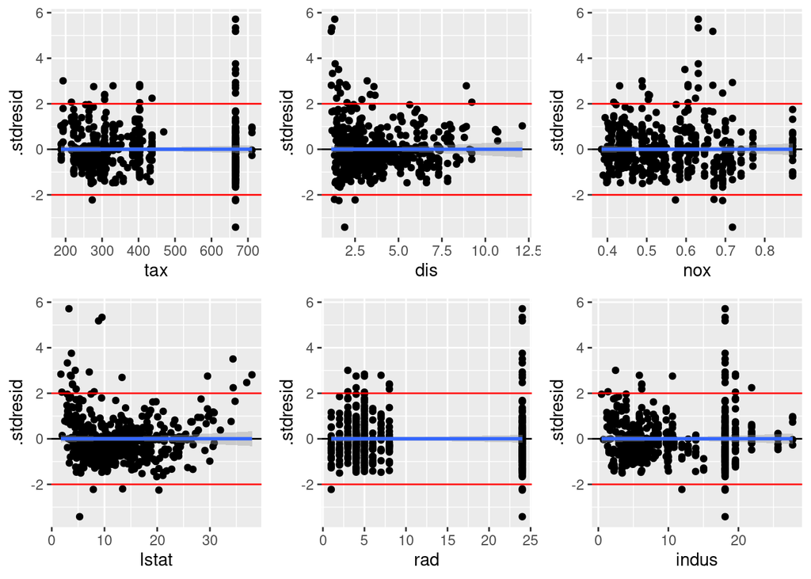

```r
res_1 <- gg_resid + aes(x = tax)
res_2 <- gg_resid + aes(x = dis)
res_3 <- gg_resid + aes(x = nox)
res_4 <- gg_resid + aes(x = lstat)
res_5 <- gg_resid + aes(x = rad)
res_6 <- gg_resid + aes(x = indus)
grid.arrange(res_1, res_2, res_3, res_4, res_5, res_6, nrow = 2)
```

После фильтрации модели практически ничего не изменилось. Вероятно, это происходит из-за того, что между предикторами есть сильная корреляция. Стоит ли вернуть предикторы в модель? Вопрос пока открытый.

Чуть позже мы попробуем откорретикровать модель.

# 3. Предсказания

На данный момент после удаления коллинеарных предикторов самый важный из оставшихся предикторов – *rm*. Сделаем искусственный датасет и предскажем для него значения *medv*.

С факторной переменной *chas* несколько сложнее. От нее нельзя получить средние значения. Но мы можем добавить их в датасет в той же пропорции, что и в оригинальных данных, и тем самым получить правильные значения и правильные выводы.

```r
table(data$chas)
```

```
##
##   0   1
## 471  35
```

Итого имеем 471х0 и 35х1 значений. Отношение = 93% : 7 %. Для датасета в 100 значений соответственно понадобится 93х0 и 7х1. Чтобы не было “ступеньки” в конце или начале, перемешаем значения рандомно. Для воспроизовдимости поставим *seed()*.

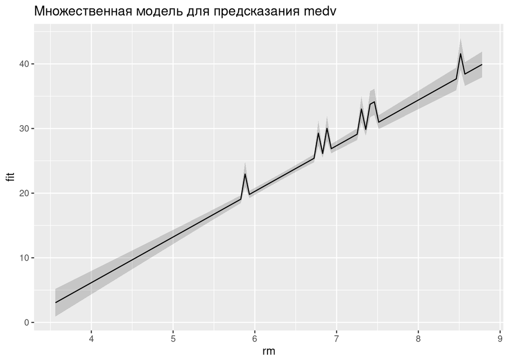

```r
set.seed(2020)
test_data <- data.frame(
  rm = seq(min(data$rm), max(data$rm), length.out = 100),
  crim = mean(data$crim),
  zn = mean(data$zn),
  chas = as.factor(sample(c(rep(0, 93),rep(1,7)))) ,
  age = mean(data$age),
  ptratio = mean(data$ptratio),
  black = mean(data$black))

pred <- predict(mod_7, newdata = test_data,  interval = 'confidence')
test_data <- data.frame(test_data, pred)

# График предсказаний модели
Pl_predict <- ggplot(test_data, aes(x = rm, y = fit)) +
  geom_ribbon(alpha = 0.2, aes(ymin = lwr, ymax = upr)) +
  geom_line() +
  ggtitle("Множественная модель для предсказания medv")
Pl_predict
```

Итак, предсказание построено. К сожеланию, факторная переменная *chas* портит красивый внешний вид графика. Но выкинуть ее мы не имеем права.

На этом заканчивается обязательная часть работы.

# 4. Дополнительная часть

## 4.1. Пошаговый отбор предикторов по значимости

Меня не оставляет мысль попробовать улучшить нашу модель. 63% точности – далеко не идеальный результат. Попробуем отобрать самые значимые предикторы из тех, что остались после удаления коллинераных предикторов. Есть несколько алгоритмов отбора предикторов. Мы будем использовать **backward selection**.

В качестве критерия отбора будем использовать **частный F-test**. В R удобнее пользоваться функцией `drop1()`. Она сравнивает полную модель с моделью, из которой удален предиктор. И делает это последовательно для всех предикторов в модели. Если удаление предиктора незначимо влияет на количество объясненной с помощью модели изменчивости, то такой предиктор можно удалять.

```r
drop1(mod_7, test = "F")
```

```
## Single term deletions
##
## Model:
## medv ~ crim + zn + chas + rm + age + ptratio + black
##         Df Sum of Sq   RSS    AIC  F value    Pr(>F)
## <none>               15509 1747.9
## crim     1     323.2 15832 1756.3  10.3772 0.0013592 **
## zn       1       1.6 15511 1745.9   0.0506 0.8220598
## chas     1     386.8 15896 1758.3  12.4206 0.0004638 ***
## rm       1   10225.3 25734 2002.1 328.3350 < 2.2e-16 ***
## age      1     411.9 15921 1759.1  13.2258 0.0003049 ***
## ptratio  1    1514.7 17024 1793.0  48.6365 9.843e-12 ***
## black    1     781.1 16290 1770.7  25.0805 7.646e-07 ***
## ---
## Signif. codes:  0 '***' 0.001 '**' 0.01 '*' 0.05 '.' 0.1 ' ' 1
```

```r
mod_8 <- update(mod_7, .~. - zn)
drop1(mod_8, test = "F")
```

```
## Single term deletions
##
## Model:
## medv ~ crim + chas + rm + age + ptratio + black
##         Df Sum of Sq   RSS    AIC F value    Pr(>F)
## <none>               15511 1745.9
## crim     1     329.2 15840 1754.5  10.591 0.0012133 **
## chas     1     390.0 15901 1756.5  12.546 0.0004342 ***
## rm       1   10413.2 25924 2003.8 335.006 < 2.2e-16 ***
## age      1     514.5 16025 1760.4  16.553 5.498e-05 ***
## ptratio  1    1605.3 17116 1793.7  51.644 2.440e-12 ***
## black    1     780.3 16291 1768.8  25.103 7.559e-07 ***
## ---
## Signif. codes:  0 '***' 0.001 '**' 0.01 '*' 0.05 '.' 0.1 ' ' 1
```

После *VIF selection* и *backward selection* мы потеряли 1 предиктор(*zn*).Надеюсь, мы не слишком потеряем в точности.

```r
summary(mod_8)
```

```
##
## Call:
## lm(formula = medv ~ crim + chas + rm + age + ptratio + black,
##     data = data)
##
## Residuals:
##     Min      1Q  Median      3Q     Max
## -19.318  -2.932  -0.746   1.713  39.705
##
## Coefficients:
##              Estimate Std. Error t value Pr(>|t|)
## (Intercept) -7.245637   4.088115  -1.772 0.076944 .
## crim        -0.108389   0.033305  -3.254 0.001213 **
## chas1        3.530804   0.996814   3.542 0.000434 ***
## rm           7.051342   0.385253  18.303  < 2e-16 ***
## age         -0.040162   0.009871  -4.069 5.50e-05 ***
## ptratio     -0.919850   0.127999  -7.186 2.44e-12 ***
## black        0.014975   0.002989   5.010 7.56e-07 ***
## ---
## Signif. codes:  0 '***' 0.001 '**' 0.01 '*' 0.05 '.' 0.1 ' ' 1
##
## Residual standard error: 5.575 on 499 degrees of freedom
## Multiple R-squared:  0.6369, Adjusted R-squared:  0.6325
## F-statistic: 145.9 on 6 and 499 DF,  p-value: < 2.2e-16
```

Радует, что модель не потеряла в точности.

## 4.2. Диагностика модели

Для множественной модели необходима такая же диагностика, что и для простой.

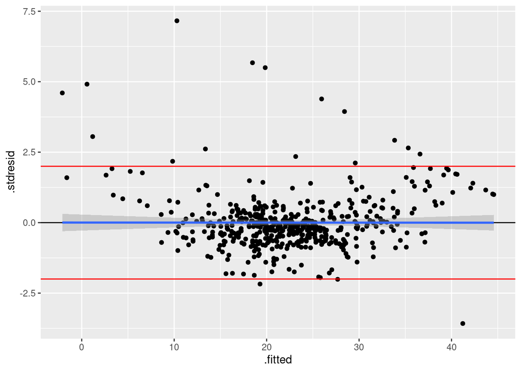

```r
mod_8_diag <- data.frame(fortify(mod_8))

gg_resid_1 <- ggplot(data = mod_8_diag, aes(x = .fitted, y = .stdresid)) +
  geom_point() +
  geom_hline(yintercept = 0) +
  geom_smooth(method = "lm") +
  geom_hline(yintercept = 2, color = "red") +
  geom_hline(yintercept = -2, color = "red")
gg_resid_1
```

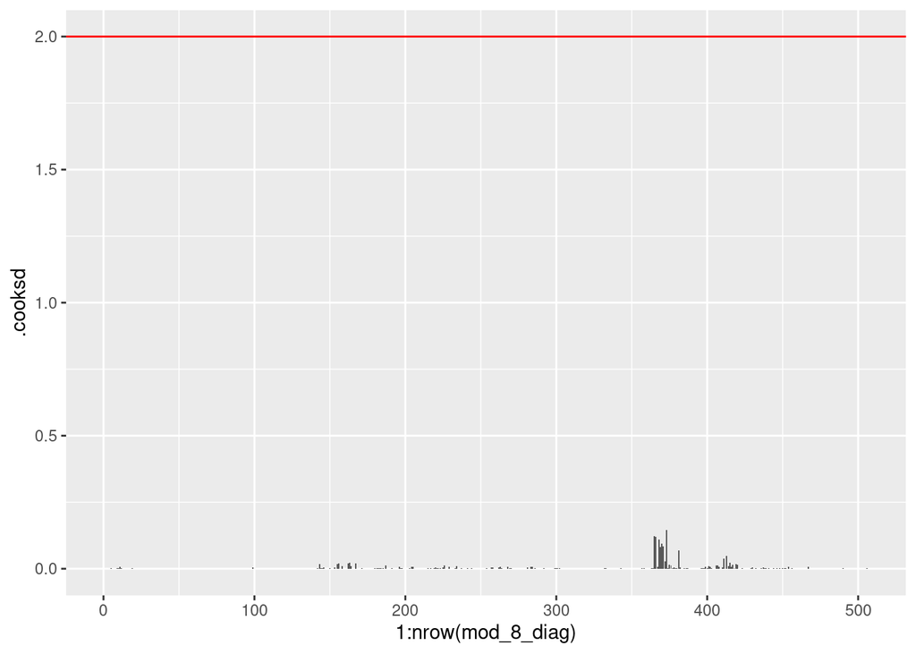

```r
ggplot(mod_8_diag, aes(x = 1:nrow(mod_8_diag), y = .cooksd)) +
  geom_bar(stat = "identity") +
  geom_hline(yintercept = 2, color = "red")
```

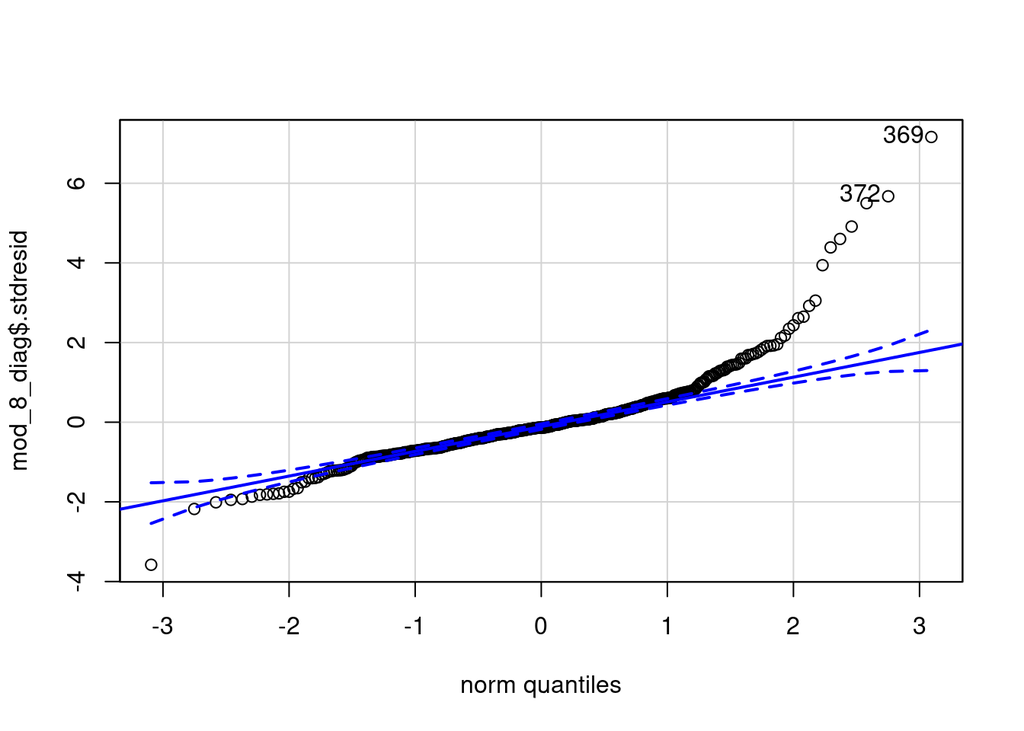

```
## [1] 369 372
```

```r
qqPlot(mod_8_diag$.stdresid)
```

И график остатков для удаленного предиктора:

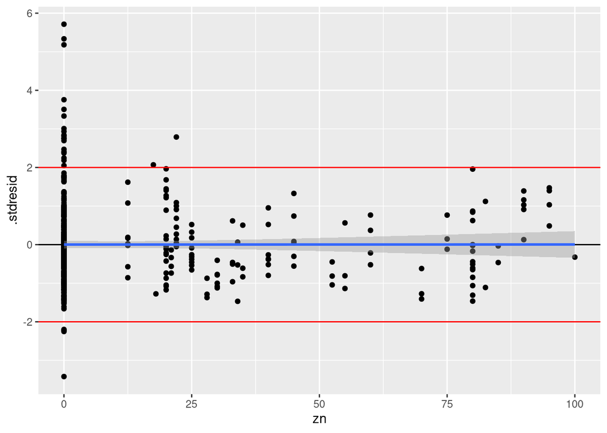

```r
res_7 <- gg_resid + aes(x = zn)
plot(res_7)
```

По результатам коррекции мы видим неприемлимые для нас вещи…

1. Распределение перестало быть нормальным. Так что лин. модели использовать в таком случае нельзя. Попробуем прологарифмировать. Мб условия применимости вернутся в норму.
2. Волнует еще то, что несмотря на отбор, точность остается достаточно низкой. Попробуем вернуть в модель некоторые из важных предикторов, даже несмотря на их VIF > 2.

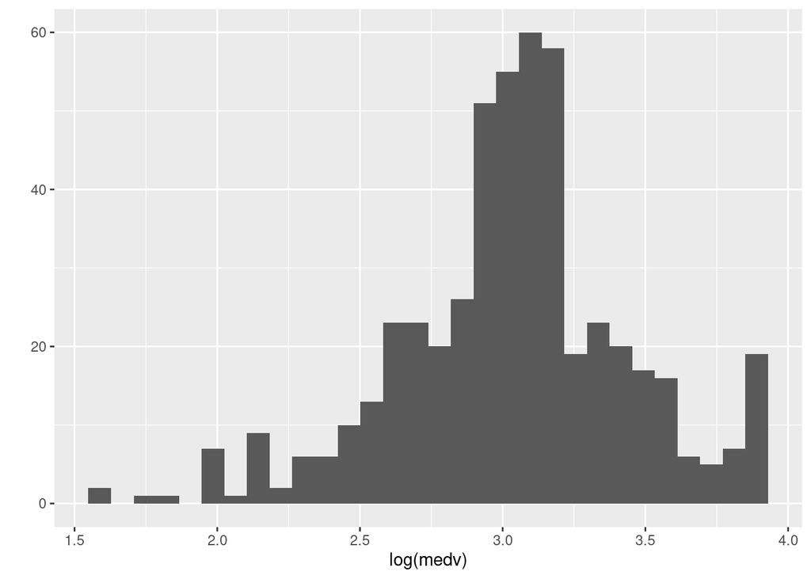

```r
qplot(x=log(medv),data=data,geom='histogram')
```

Уже лучше Хоть и есть некоторое смещение вправо, предлагаю в дальнейшем сторить лин. модель для логарифимрованных данных.

Тогда обновим модель:

```r
mod_8_log <- lm(formula = log(medv) ~ crim + chas + rm + age + ptratio + black,
    data = data)
```